# Lab05 - Estimator evaluation

Jarad Niemi

2018-02-13

To follow along, use the lab05 code and install the `plyr` and `ggplot2` packages (if they are not already installed). If you are on a lab computer, these will already be installed.

```r
install.packages(c("plyr","ggplot2"))
```

## Binomial probability of success estimation

Let’s let $y\sim Bin(n,\theta)$. Recall that the MLE is $\hat{\theta}_{MLE} = \frac{y}{n}$. If we assume the prior $\theta \sim Be(a,b)$, then the posterior is $\theta|y \sim Be(a+y,b+n-y)$ and the posterior expectation is
$$\hat{\theta}_{Bayes} = E[\theta|y] = \frac{a+y}{a+b+n}.$$
Specifically, if we assume a Uniform prior on (0,1), i.e. $a=b=1$, then $\theta|y \sim Be(1+y,1+n-y)$ and the posterior expectation is
$$\hat{\theta}_{Bayes} = E[\theta|y] = \frac{1+y}{2+n}.$$
This is equivalent to adding one success and one failure to the data.

Suppose you randomly sample 22 buildings in Ames and find that 15 of them are residential buildings. Then the MLE for the probability of a building in Ames being residential is

```r
n <- 22
y <- 15
(mle <- y/n)
```

```
## [1] 0.6818182
```

the Bayes estimator is

```r
a <- b <- 1
(bayes <- (a+y)/(a+b+n))
```

```
## [1] 0.6666667
```

and a 95% credible interval is

```r
qbeta(c(.025,.975), a+y, b+n-y)
```

```
## [1] 0.4708083 0.8362364
```

#### Binomial posterior activity

```r
n <- 222
y <- 153
(mle <- y/n)
```

```
## [1] 0.6891892
```

```r
(bayes <- (a+y)/(a+b+n))
```

```
## [1] 0.6875
```

```r
qbeta(c(.05,.95), a+y, b+n-y)
```

```
## [1] 0.6357203 0.7373720
```

Can you calculate a posterior median?

## Parameter estimation

Recall that estimators have the properties

- [Bias](https://en.wikipedia.org/wiki/Bias_of_an_estimator)
- [Consistency](https://en.wikipedia.org/wiki/Consistent_estimator)

In addition, uncertainty intervals, i.e. credible intervals, have a property called

- [Coverage](https://en.wikipedia.org/wiki/Coverage_probability)

### Bias

The bias of an estimator is the expected value of the estimator minus the true value. Generally, we don’t know the true value, but we can simulate data with a known truth. We can estimate the bias, by performing repeated simulations and taking the average value of the estimator across those simulations. This average value is an estimate of the expected value. If we take enough values in the average, then the Central Limit Theorem tells us the distribution of this average. Specifically

$$\overline{x} \sim N(\mu,\sigma^2/n)$$
where $\mu=E[\overline{x}]$ and we estimate $\sigma^2$ with the sample variance.

#### Binomial model

Let’s use simulations, i.e. Monte Carlo, to estimate the bias of the MLE and Bayes estimator. To do this, we are going to repeatedly

1. simulate binomial random variables with $n=10$ and $\theta=0.5$,
2. compute the MLE and Bayes estimator

Then we will

1. take an average of all the MLE estimates and subtract $\theta$ (the true value)
2. take an average of all the Bayes estimates and subtract $\theta$ (the true value)

```r
n <- 10
theta <- 0.5

n_reps <- 1e4
mle <- numeric(n_reps)
bayes <- numeric(n_reps)

for (i in 1:n_reps) {
  y <- rbinom(1, size = n, prob = theta)
  mle[i] <- y/n
  bayes[i] <- (a+y)/(a+b+n)
}


mean(mle)  - theta # estimate of MLE bias
```

```
## [1] 0.00077
```

```r
mean(bayes)- theta # estimate of Bayes bias
```

```
## [1] 0.0006416667
```

Now, we probably want some idea of how close we are to the true bias. We will use the CLT.
$$\overline{\hat{\theta}} \pm z_{0.025} SE(\overline{\hat{\theta}})$$
where the $SE(\overline{\hat{\theta}})$ is estimated by the sample standard deviation of $\hat{\theta}$ divided by the square root of the number of values in the average, i.e. the sample size. The formula for a 95% interval is then
$$\overline{\hat{\theta}} \pm z_{0.025} s_{\hat{\theta}}/\sqrt{n}$$

```r
mean(mle  ) + c(-1,1)*qnorm(.975)*sd(mle  )/sqrt(length(mle  )) - theta
```

```
## [1] -0.002349173  0.003889173
```

```r
mean(bayes) + c(-1,1)*qnorm(.975)*sd(bayes)/sqrt(length(bayes)) - theta
```

```
## [1] -0.001957644  0.003240977
```

We could have written the code a bit more succinctly (and, perhaps, obtusely).

```r
y <- rbinom(n_reps, size = n, prob = theta)
mle   <- y/n
bayes <- (a+y)/(a+b+n)

mean(mle  ) + c(-1,1)*qnorm(.975)*sd(mle  )/sqrt(length(mle  )) - theta
```

```
## [1] -0.001979445  0.004299445
```

```r
mean(bayes) + c(-1,1)*qnorm(.975)*sd(bayes)/sqrt(length(bayes)) - theta
```

```
## [1] -0.001649538  0.003582871
```

#### Binomial bias activity

Repeat the simulation procedure we had above, but using $n=5$ and $\theta=0.2$. What do you find for the bias of the MLE and the Bayes estimator?

```r
n <- 5
theta <- 0.2

y <- rbinom(n_reps, size = n, prob = theta)
mle   <- y/n
bayes <- (a+y)/(a+b+n)

mean(mle  ) + c(-1,1)*qnorm(.975)*sd(mle  )/sqrt(length(mle  )) - theta
```

```
## [1] -0.004117623  0.002917623
```

```r
mean(bayes) + c(-1,1)*qnorm(.975)*sd(bayes)/sqrt(length(bayes)) - theta
```

```
## [1] 0.08277313 0.08779830
```

So the Bayes estimator appears to be quite biased.

#### Binomial bias simulation study

Let’s study what happens to the bias of the Bayes estimator as we change $n$ and $\theta$. The following will look at $n=1,10,100,1000$ and $\theta$ from $0$ to $1$ in increments of 0.1.

```r
settings <- expand.grid(n = 10^(0:3),
                        theta = seq(0,1,by=0.1))
```

We will use the [plyr](https://cran.r-project.org/web/packages/plyr/index.html) package to help us iterate over all of these values of $n$ and $\theta$. If the `plyr` package isn’t installed, you will need to install it using the command below:

```r
install.packages("plyr")
```

Then make sure to load the package using

```r
library("plyr")
```

The `plyr` package has a function called `ddply` which expects a `data.frame` as input (thus the first d) and returns a `data.frame` as output (thus the second d).

Check the help file to learn about the function.

```r
?plyr
```

We will use the first three arguments to loop over $n$ and $\theta$ and to perform our simulation study.

```r
sim_study <- ddply(settings, .(n, theta), function(x) {
  y     <- rbinom(1e4, size = x$n, prob = x$theta)
  mle   <- y/x$n
  bayes <- (a+y)/(a+b+x$n)

  d <- data.frame(
    estimator = c("mle", "bayes"),
    bias      = c(mean(mle), mean(bayes)) - x$theta,
    var       = c(var( mle), var( bayes)))

  # d$se    <- sqrt(d$var / x$n)
  # d$lower <- d$bias-qnorm(.975)*d$se
  # d$upper <- d$bias+qnorm(.975)*d$se

  return(d)
})
```

To plot this, we will use the [ggplot2](https://cran.r-project.org/web/packages/ggplot2/index.html) package which you may need to install.

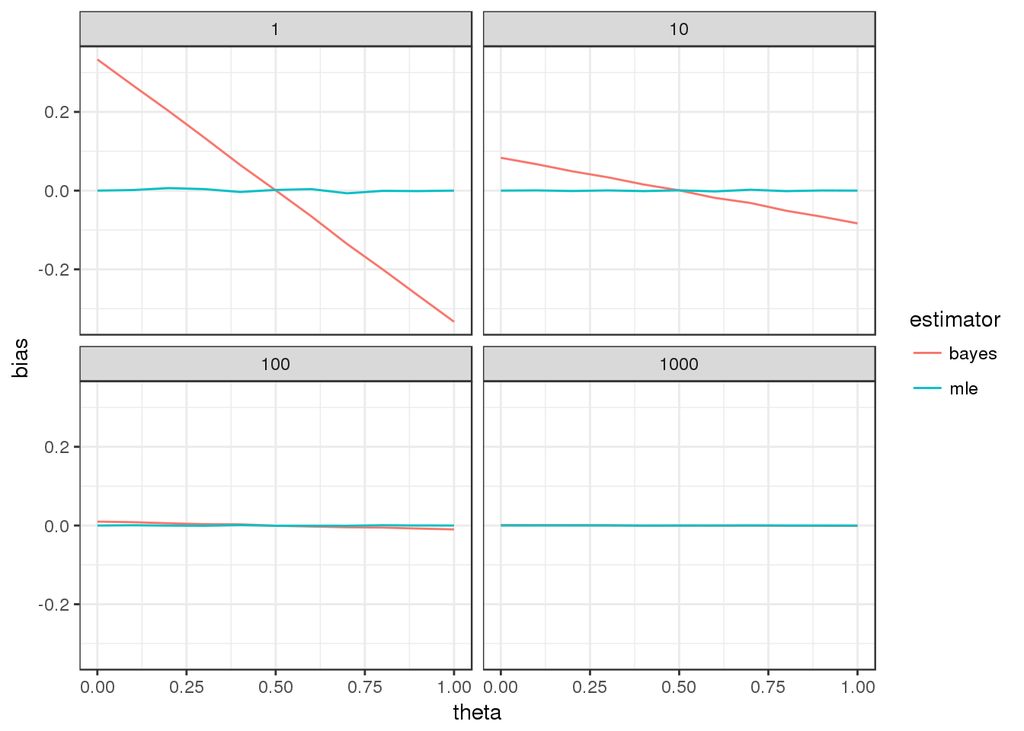

```r
library("ggplot2")

ggplot(sim_study, aes(x=theta, y=bias, color=estimator)) +
  geom_line() +
  facet_wrap(~n) +
  theme_bw()
```

We can see that the Bayes estimator has the most bias when 1) the sample size is small and 2) $\theta$ is far away from 0.5. But the variance of the Bayes estimator is smaller than the variance of the MLE estimator.

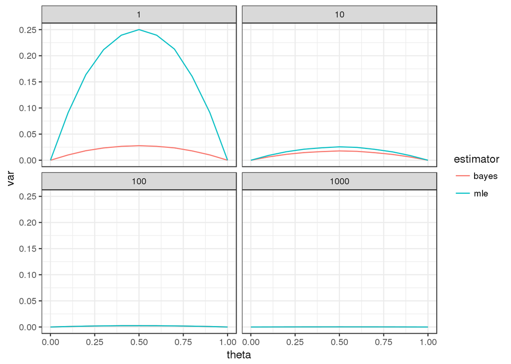

```r
library("ggplot2")

ggplot(sim_study, aes(x=theta, y=var, color=estimator)) +
  geom_line() +
  facet_wrap(~n) +
  theme_bw()
```

We can see that the Bayes estimator always has smaller variance than the MLE.

Thus, we often use a new property of an estimator called the [mean squared error (MSE)](https://en.wikipedia.org/wiki/Mean_squared_error):
$$MSE(\hat{\theta}) =
E[(\hat\theta-\theta)^2] =
Var(\hat{\theta}) + Bias(\hat{\theta},\theta)^2$$
This property combines both the bias and the variance into a single term. Generally the estimator with the smallest MSE should be utilized.

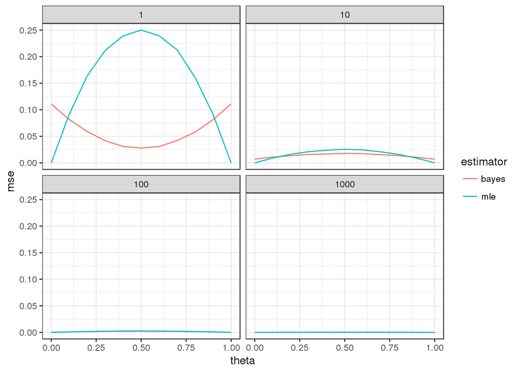

```r
sim_study$mse <- sim_study$var + sim_study$bias^2

ggplot(sim_study, aes(x=theta, y=mse, color=estimator)) +
  geom_line() +
  facet_wrap(~n) +
  theme_bw()
```

#### Binomial MSE activity

Generate a curve for the MSE for the MLE and Bayes estimators for a binomial probability of success when $n=13$ for various values of $\theta$.

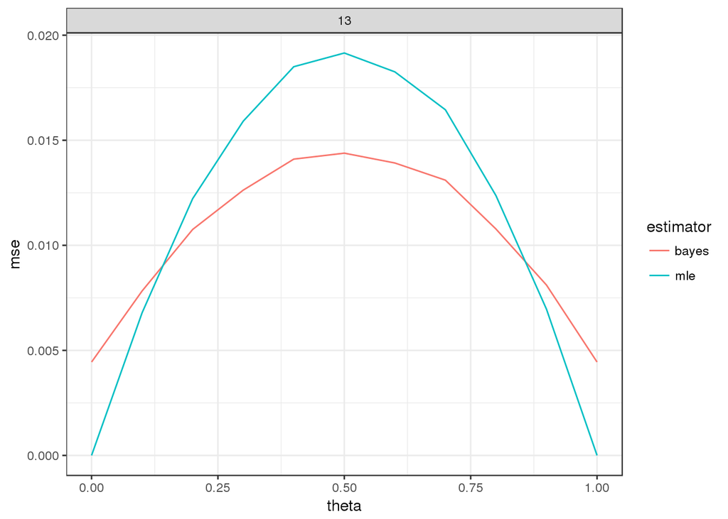

```r
settings <- expand.grid(n = 13,
                        theta = seq(0,1,by=0.1))

sim_study <- ddply(settings, .(n, theta), function(x) {
  y     <- rbinom(1e4, size = x$n, prob = x$theta)
  mle   <- y/x$n
  bayes <- (a+y)/(a+b+x$n)

  d <- data.frame(
    estimator = c("mle", "bayes"),
    bias      = c(mean(mle), mean(bayes)) - x$theta,
    var       = c(var( mle), var( bayes)))
  d$mse <- d$var + d$bias^2

  return(d)
})

ggplot(sim_study, aes(x=theta, y=mse, color=estimator)) +
  geom_line() +
  facet_wrap(~n) + # This line isn't necessary
  theme_bw()
```

Why does the alternative approach give the same answer? (I’m not sure what I mean by this.)

### Consistency

Recall that an estimator is consistent if
$$P(|\hat\theta_n-\theta|<\epsilon) \to 1 \quad\mbox{ as }\quad n\to\infty$$
for any $\epsilon>0$. Here I have made explicit that the estimator depends on $n$.

To evaluate consistency by simulation, we will perform a sequence of experiments, i.e. one coin flip at a time, and calculate the estimator after each coin flip. Then we will see how many times the estimator is more than $\epsilon$ away from $\theta$.

```r
theta = 0.51
n_max <- 1e3

d <- ddply(data.frame(rep=1:1e3), .(rep), function(x) {
  x <- rbinom(n_max, size = 1, prob = theta)

  mle <- bayes <- numeric(n_max)
  for (n in 1:n_max) {
    y <- sum(x[1:n])
    mle[n] <- y/n
    bayes[n] <- (a+y)/(a+b+n)
  }

  data.frame(n     = 1:n_max,
             mle   = mle,
             bayes = bayes)
})

epsilon <- 0.05
sum <- ddply(d, .(n), function(x) {
  data.frame(estimator = c("mle","bayes"),
             prob = c(mean(abs(x$mle   - theta) < epsilon),
                      mean(abs(x$bayes - theta) < epsilon)))
})
```

Now plot the results

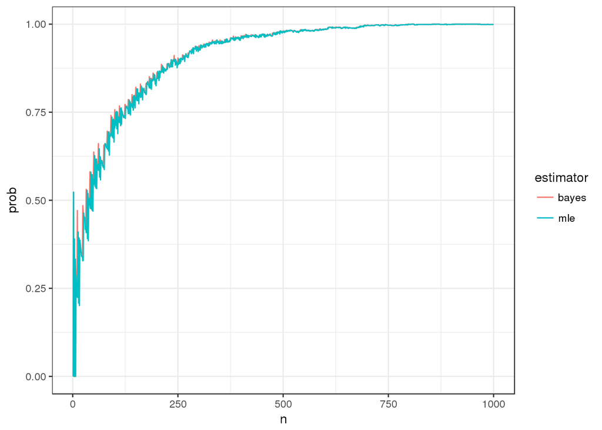

```r
ggplot(sum, aes(x=n, y=prob, color=estimator)) +
  geom_line() +
  theme_bw()
```

This is an illustration of the property called consistency. For both the Bayes estimator and the MLE, the probability of being within $\epsilon$ of $\theta$ (the true success probability) converges to 1 as the number of observations increases.

#### Binomial consistency activity

Via simulation, show that if $\theta=0.01$ that both the MLE and Bayes estimators are consistent.

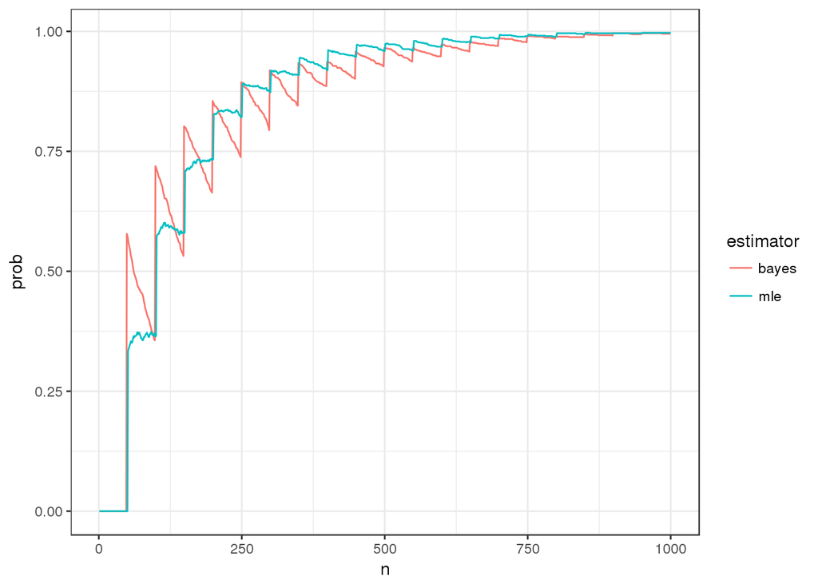

```r
theta = 0.01
n_max <- 1e3

d <- ddply(data.frame(rep=1:1e3), .(rep), function(x) {
  x <- rbinom(n_max, size = 1, prob = theta)

  mle <- bayes <- numeric(n_max)
  for (n in 1:n_max) {
    y <- sum(x[1:n])
    mle[n] <- y/n
    bayes[n] <- (a+y)/(a+b+n)
  }

  data.frame(n     = 1:n_max,
             mle   = mle,
             bayes = bayes)
})

epsilon <- 0.01
sum <- ddply(d, .(n), function(x) {
  data.frame(estimator = c("mle","bayes"),
             prob = c(mean(abs(x$mle   - theta) < epsilon),
                      mean(abs(x$bayes - theta) < epsilon)))
})

ggplot(sum, aes(x=n, y=prob, color=estimator)) +
  geom_line() +
  theme_bw()
```

### Coverage

Uncertainty intervals have a property called [coverage](https://en.wikipedia.org/wiki/Coverage_probability). Coverage is the probability the interval will contain the truth when the method used to construct the interval is used repeatedly on different data sets.

We will evaluate coverage using simulations by repeatedly

1. Simulating data
2. Creating a credible interval
3. Determining how often that credible interval contains the truth

```r
n <- 100
theta <- 0.5

n_reps <- 1e4
y <- rbinom(n_reps, size = n, prob = theta)

lower <- qbeta(.025, a+y, b+n-y)
upper <- qbeta(.975, a+y, b+n-y)

mean( lower < theta & theta < upper )
```

```
## [1] 0.945
```

If we want to understand our Monte Carlo uncertainty in this coverage, we can use the CLT for a proportion.

```r
p <- mean( lower < theta & theta < upper)

p + c(-1,1)*qnorm(.975)*sqrt(p*(1-p)/n_reps)
```

```
## [1] 0.9405317 0.9494683
```

#### Binomial coverage activity

Via simulation, determine the coverage for a credible interval when $n=10$ and $\theta = 0.2$ and use the CLT to provide an uncertainty on this coverage.

```r
n <- 10
theta <- 0.2

n_reps <- 1e4
y <- rbinom(n_reps, size = n, prob = theta)

lower <- qbeta(.025, a+y, b+n-y)
upper <- qbeta(.975, a+y, b+n-y)

(p <- mean( lower < theta & theta < upper))
```

```
## [1] 0.9667
```

```r
p + c(-1,1)*qnorm(.975)*sqrt(p*(1-p)/n_reps)
```

```
## [1] 0.9631835 0.9702165
```

Now try with $\theta=0.01$.

#### Binomial coverage simulation study

Let’s now look at coverage across a wide range of $n$ and $\theta$.

```r
settings <- expand.grid(n = 10^(0:3),
                        theta = seq(0,1,by=0.1))

sim_study <- ddply(settings, .(n, theta), function(x) {
  y     <- rbinom(1e4, size = x$n, prob = x$theta)
  mle   <- y/x$n
  bayes <- (a+y)/(a+b+x$n)

  lower <- qbeta(.025, a+y, b+x$n-y)
  upper <- qbeta(.975, a+y, b+x$n-y)

  data.frame(coverage = mean( lower <= x$theta & x$theta <= upper))
})
```

Now plot the results

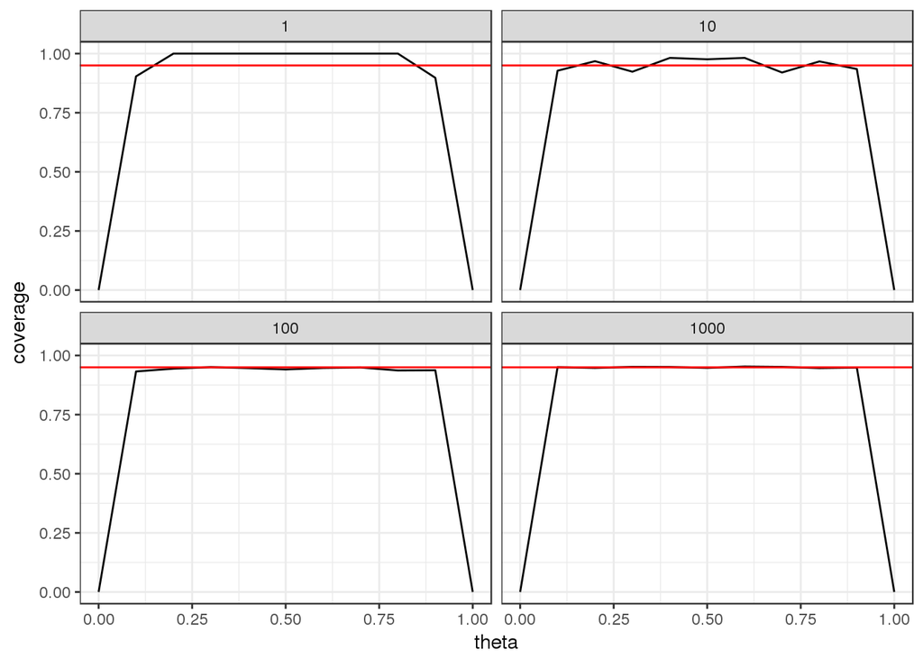

```r
ggplot(sim_study, aes(x=theta, y=coverage)) +
  geom_line() +
  facet_wrap(~n) +
  geom_hline(yintercept = 0.95, color = "red") +
  ylim(0,1) +
  theme_bw()
```

The coverage is extremely poor when $\theta$ is 0 (or 1) because $y$ is always 0 (or $n$). In these cases, a simple way to fix the interval is to use a one-sided interval when $y$ is 0 (or $n$). Specifically,

- if $y=0$, then use the one-sided interval (0,U)
- if $y=n$, then use the one-sided interval (L,1)

```r
sim_study <- ddply(settings, .(n, theta), function(x) {
  y     <- rbinom(1e4, size = x$n, prob = x$theta)
  mle   <- y/x$n
  bayes <- (a+y)/(a+b+x$n)

  lower <- qbeta(.025, a+y, b+x$n-y)
  upper <- qbeta(.975, a+y, b+x$n-y)

  # Fix intervals when y=0
  lower[y==0] <- 0
  upper[y==0] <- qbeta(.95, a+0, b+x$n-0)

  # Fix intervals when y=n
  upper[y==x$n] <- 1
  lower[y==x$n] <- qbeta(.05, a+x$n, b+x$n-x$n)

  data.frame(coverage = mean( lower <= x$theta & x$theta <= upper))
})
```

Now plot the results

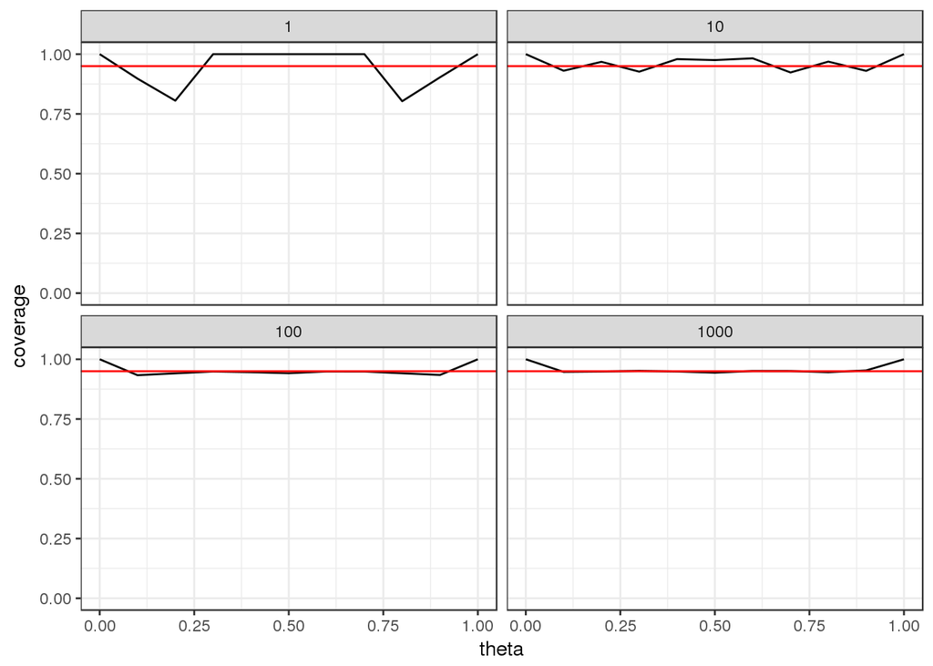

```r
ggplot(sim_study, aes(x=theta, y=coverage)) +
  geom_line() +
  facet_wrap(~n) +
  geom_hline(yintercept = 0.95, color = "red") +
  ylim(0,1) +
  theme_bw()
```

The plot here has been constructed to have y-axis limits set to 0 and 1 for comparison with the previous plot.

#### Coverage for Jeffreys prior

In this class, we will use a uniform prior for the probability. An alternative is to use Jeffreys prior which is $Be(0.5,0.5)$. Run a simulation study to look at coverage for Jeffreys prior.

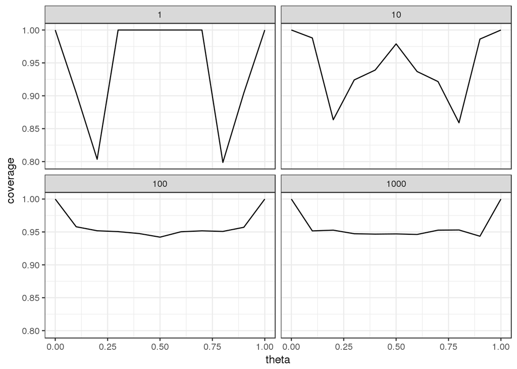

```r
a <- b <- 0.5
sim_study <- ddply(settings, .(n, theta), function(x) {
  y     <- rbinom(1e4, size = x$n, prob = x$theta)
  mle   <- y/x$n
  bayes <- (a+y)/(a+b+x$n)

  lower <- qbeta(.025, a+y, b+x$n-y)
  upper <- qbeta(.975, a+y, b+x$n-y)

  # Fix intervals when y=0
  lower[y==0] <- 0
  upper[y==0] <- qbeta(.95, a+0, b+x$n-0)

  # Fix intervals when y=n
  upper[y==x$n] <- 1
  lower[y==x$n] <- qbeta(.05, a+x$n, b+x$n-x$n)

  data.frame(coverage = mean( lower <= x$theta & x$theta <= upper))
})

ggplot(sim_study, aes(x=theta, y=coverage)) +
  geom_line() +
  facet_wrap(~n) +
  theme_bw()
```